# 2019_04_15_genbygen_segmentation_and_stability_analysis.Rmd

Toni Beltran

15/04/2019

```r
library(gplots)
library(RColorBrewer)
library(ggplot2)
library(depmixS4)
library(DESeq2)
setwd("/Users/ab6415/Bioinformatics/Analysis/EpiMALs_PAPER_ANALYSES/05_Figure3/")

ttg_DEseqnorm<-read.table("../02_Normalised_counts/22G_DEseqnorm_counts_averaged.txt")
ttg_MAplot_data<-read.table("../03_Figure1/MAplot_filtering_22Gs_genbygen_p1e-2.txt",header=TRUE)
ttg_MAplot_data<-ttg_MAplot_data[which(ttg_MAplot_data$padj<1e-4),]

summary_stats_A<-data.frame(mean=apply(ttg_DEseqnorm[,1:12],MARGIN=1,FUN = mean),
                            min=apply(ttg_DEseqnorm[,1:12],MARGIN=1,FUN = min))

summary_stats_B<-data.frame(mean=apply(ttg_DEseqnorm[,13:24],MARGIN=1,FUN = mean),
                            min=apply(ttg_DEseqnorm[,13:24],MARGIN=1,FUN = min))

summary_stats_AB<-data.frame(mean=apply(ttg_DEseqnorm[,1:24],MARGIN = 1,FUN=mean),
                             min=apply(ttg_DEseqnorm[,1:24],MARGIN = 1,FUN=min))
```

```r
library(DESeq2)
ttg_A_rawcounts<-read.table("../01_Raw_counts/RAW_22G_COUNTS/22G_RAW_COUNTS_lineageA.txt")
ttg_B_rawcounts<-read.table("../01_Raw_counts/RAW_22G_COUNTS/22G_RAW_COUNTS_lineageB.txt")
ttg_AB_rawcounts<-merge(ttg_A_rawcounts,ttg_B_rawcounts,by=0); rownames(ttg_AB_rawcounts)<-ttg_AB_rawcounts$Row.names; ttg_AB_rawcounts$Row.names<-NULL

cds<-DESeqDataSetFromMatrix(countData = ttg_AB_rawcounts,
                            colData = data.frame(line=colnames(ttg_AB_rawcounts),condition=as.factor(rep(c(rep(1,7),rep(2,5)),2))),
                            design= ~condition)
dds<-DESeq(cds)
```

```
## -- replacing outliers and refitting for 21 genes
## -- DESeq argument 'minReplicatesForReplace' = 7
## -- original counts are preserved in counts(dds)
```

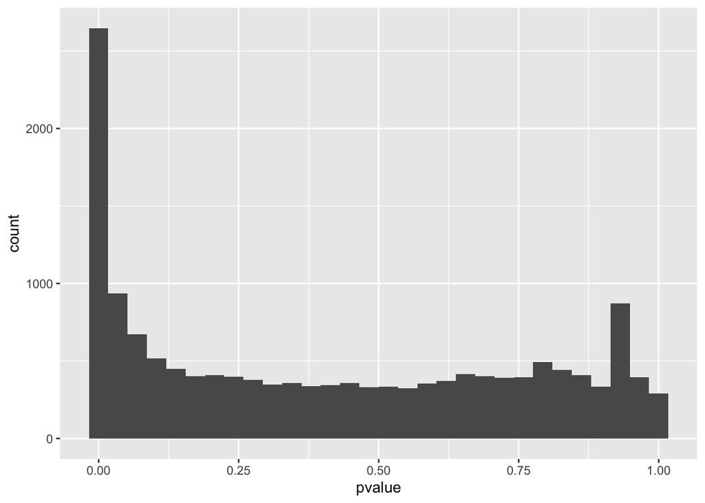

```r
res<-results(dds)
res<-res[order(res$padj,decreasing = FALSE),]

ggplot(as.data.frame(res))+geom_histogram(aes(x=pvalue))
```

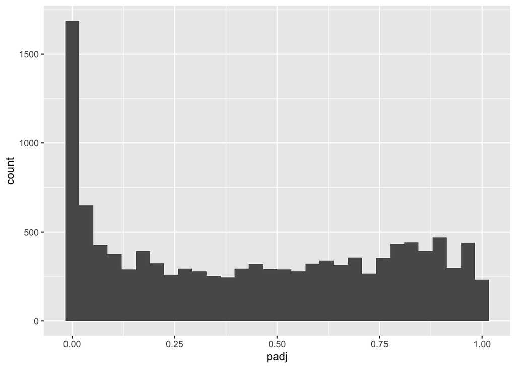

```r
ggplot(as.data.frame(res))+geom_histogram(aes(x=padj))
```

```r
removegenes_lastfive<-rownames(res[which(res$padj<0.2 & abs(res$log2FoldChange)>1),])


cds<-DESeqDataSetFromMatrix(countData = ttg_AB_rawcounts,
                            colData = data.frame(line=colnames(ttg_AB_rawcounts),condition=as.factor(c(rep(1,12),2,rep(1,3),2,rep(1,7)))),
                            design= ~condition)
dds<-DESeq(cds)
```

```
## -- replacing outliers and refitting for 41 genes
## -- DESeq argument 'minReplicatesForReplace' = 7
## -- original counts are preserved in counts(dds)
```

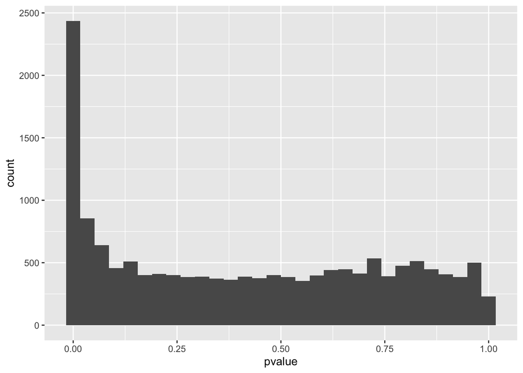

```r
res<-results(dds)
res<-res[order(res$padj,decreasing = FALSE),]

ggplot(as.data.frame(res))+geom_histogram(aes(x=pvalue))
```

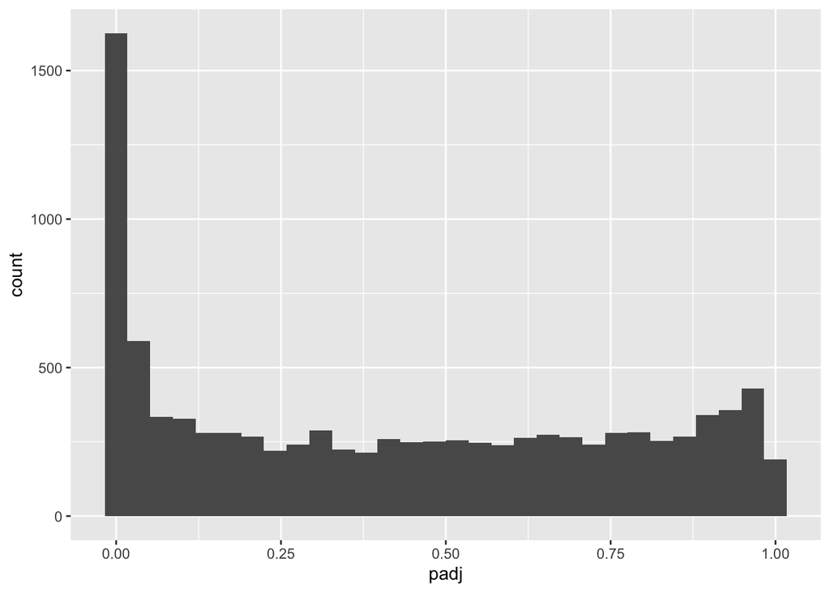

```r
ggplot(as.data.frame(res))+geom_histogram(aes(x=padj))
```

```r
removegenes_b1_b5<-rownames(res[which(res$padj<0.2 & abs(res$log2FoldChange)>1),])

removegenes<-union(removegenes_lastfive,removegenes_b1_b5)
length(removegenes)
```

```
## [1] 2121
```

```r
epimutable_genes_genbygen<-unique(ttg_MAplot_data$ID)
epimutable_genes_genbygen<-epimutable_genes_genbygen[-which(epimutable_genes_genbygen %in% removegenes)]
length(unique(epimutable_genes_genbygen))
```

```
## [1] 145
```

```r
ttg_DEseqnorm_epimutable_genes<-ttg_DEseqnorm[which(rownames(ttg_DEseqnorm) %in% epimutable_genes_genbygen),]

write.table(unique(epimutable_genes_genbygen),file="epimutable_genes_genbygen.txt")
write.table(unique(removegenes),file="removegenes.txt")
```

# Segmentation of counts data into low and high 22G counts

In this part of the code, I apply k-means clustering to the counts distributions to obtain binarized “high”-“low” small RNA count states for each gene.

```r
library(nnet)

kmeans_row<-function(vector){
  kmc<-kmeans(x = as.numeric(vector),centers=2)
  high<-kmc$cluster[which.is.max(vector)]
  if (high==2){return(kmc$cluster)
  }else{return(abs(kmc$cluster-3))}
}

kmeans_clusters_byrow_all<-matrix(0,nrow=nrow(ttg_DEseqnorm_epimutable_genes),ncol = 47)
rownames(kmeans_clusters_byrow_all)<-rownames(ttg_DEseqnorm_epimutable_genes)
for (gene in rownames(ttg_DEseqnorm_epimutable_genes)){
      kmeans_clusters_byrow_all[gene,]<-kmeans_row(ttg_DEseqnorm_epimutable_genes[gene,])
}

colnames(kmeans_clusters_byrow_all)<-colnames(ttg_DEseqnorm)

pdf("epimutations_lineageA.pdf")
heatmap.2(as.matrix(kmeans_clusters_byrow_all[,1:12]),col = colorRampPalette(c("#67a9cf","#de2d26")),Colv=FALSE,trace="none",dendrogram = "none",
          main="lineage A")
dev.off()
```

```r
pdf("epimutations_lineageB.pdf")
heatmap.2(as.matrix(kmeans_clusters_byrow_all[,13:24]),col = colorRampPalette(c("#67a9cf","#de2d26")),Colv=FALSE,trace="none",dendrogram = "none",
          main="lineage B")
dev.off()
```

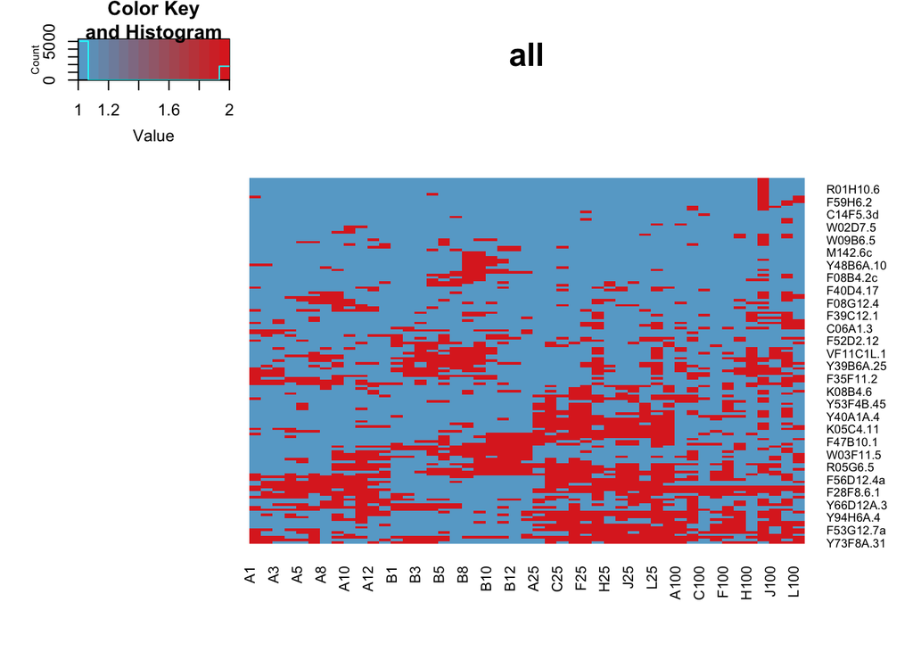

```r
heatmap.2(as.matrix(kmeans_clusters_byrow_all),col = colorRampPalette(c("#67a9cf","#de2d26")),Colv=FALSE,trace="none",dendrogram = "none",
          main="all")
```

```r
write.table(kmeans_clusters_byrow_all,file="kmeans-segmentation_p1e-4_epimutable_genes",
            quote=FALSE)
```

# Epimutation data retrieved from the segmented data

In this part of the code, I read the high-low small RNA state traces in order to retrieve the duration of high and low states from the consecutive generation data. In the end a table is generated where each row is an epimutation event, recording whether it is an increase or a decrease in small RNAs, its duration, the line in which it started, whether it is a complete or an incomplete event (reaching the end of the experiment therefore of unknown total duration).

```r
epimuts_from_kmeans_trace<-function(vect,gene){
  trace<-rle(vect)
  epimut_number<-length(trace$lengths)
  completeness<-rep(1,epimut_number); completeness[1]<-0; completeness[epimut_number]<-0;
  return(data.frame(ID=rep(gene,epimut_number),up_or_down=trace$values,duration=trace$lengths,completeness=completeness,stgen=c(-1,cumsum(trace$lengths)[1:(epimut_number-1)])))
}


epimut_duration_kmeans_A<-data.frame()
epimut_duration_kmeans_B<-data.frame()

for (gene in rownames(kmeans_clusters_byrow_all)){
  if (sum(kmeans_clusters_byrow_all[gene,1:12])>12 & sum(kmeans_clusters_byrow_all[gene,1:12])<24){
  epimut_duration_kmeans_A<-rbind(epimut_duration_kmeans_A,epimuts_from_kmeans_trace(kmeans_clusters_byrow_all[gene,1:12],gene))}
  if (sum(kmeans_clusters_byrow_all[gene,13:24])>12 & sum(kmeans_clusters_byrow_all[gene,13:24])<24){
  epimut_duration_kmeans_B<-rbind(epimut_duration_kmeans_B,epimuts_from_kmeans_trace(kmeans_clusters_byrow_all[gene,13:24],gene))
  }
}

epimut_duration_kmeans_A<-epimut_duration_kmeans_A[-which(epimut_duration_kmeans_A$stgen==-1),]
epimut_duration_kmeans_B<-epimut_duration_kmeans_B[-which(epimut_duration_kmeans_B$stgen==-1),]

#correction to incorporate missing generation 7
#assumes no change from generation 6 to 7 (overestimates duration)
epimut_duration_kmeans_A$stgen_corrected<-epimut_duration_kmeans_A$stgen
epimut_duration_kmeans_A$duration_corrected<-epimut_duration_kmeans_A$duration
for (i in seq(nrow(epimut_duration_kmeans_A))){
  if (epimut_duration_kmeans_A[i,"stgen"]>6){
  epimut_duration_kmeans_A[i,"stgen_corrected"]<-epimut_duration_kmeans_A[i,"stgen_corrected"]+1
  }
  if ((epimut_duration_kmeans_A[i,"stgen"]+epimut_duration_kmeans_A[i,"duration"])>6 & epimut_duration_kmeans_A[i,"stgen"]<7){
  epimut_duration_kmeans_A[i,"duration_corrected"]<-epimut_duration_kmeans_A[i,"duration_corrected"]+1
  }
}


epimut_duration_kmeans_B$stgen_corrected<-epimut_duration_kmeans_B$stgen
epimut_duration_kmeans_B$duration_corrected<-epimut_duration_kmeans_B$duration
for (i in seq(nrow(epimut_duration_kmeans_B))){
  if (epimut_duration_kmeans_B[i,"stgen"]>6){
  epimut_duration_kmeans_B[i,"stgen_corrected"]<-epimut_duration_kmeans_B[i,"stgen_corrected"]+1
  }
  if ((epimut_duration_kmeans_B[i,"stgen"]+epimut_duration_kmeans_B[i,"duration"])>6 & epimut_duration_kmeans_B[i,"stgen"]<7){
  epimut_duration_kmeans_B[i,"duration_corrected"]<-epimut_duration_kmeans_B[i,"duration_corrected"]+1
  }
}

epimut_duration_kmeans_A$duration<-epimut_duration_kmeans_A$duration_corrected
epimut_duration_kmeans_B$duration<-epimut_duration_kmeans_B$duration_corrected
epimut_duration_kmeans_A$stgen<-epimut_duration_kmeans_A$stgen_corrected
epimut_duration_kmeans_B$stgen<-epimut_duration_kmeans_B$stgen_corrected

epimut_duration_kmeans_A$stgen_corrected<-NULL; epimut_duration_kmeans_B$stgen_corrected<-NULL
epimut_duration_kmeans_A$duration_corrected<-NULL; epimut_duration_kmeans_B$duration_corrected<-NULL

write.table(epimut_duration_kmeans_A,file="epimut_duration_batchremoved_kmeans_linA_JOINT_p1e-4.txt",quote=FALSE)
write.table(epimut_duration_kmeans_B,file="epimut_duration_batchremoved_kmeans_linB_JOINT_p1e-4.txt",quote=FALSE)

nrow(rbind(epimut_duration_kmeans_A,epimut_duration_kmeans_B))
```

```
## [1] 528
```

# plotting the distribution of event duration

```r
##all epimutations
table(epimut_duration_kmeans_A$duration)
```

```
##
##   1   2   3   4   5   6   7   8   9  10  11  12
## 116  52  39  19  14   7   7   4   5   4   2   4
```

```r
table(epimut_duration_kmeans_A$up_or_down)
```

```
##
##   1   2
## 140 133
```

```r
table(epimut_duration_kmeans_A[which(epimut_duration_kmeans_A$completeness==0),"duration"])
```

```
##
##  1  2  3  4  5  7  8  9 10 11 12
## 25 18 14 10  8  6  3  3  4  1  4
```

```r
table(epimut_duration_kmeans_A[which(epimut_duration_kmeans_A$completeness==1),"duration"])
```

```
##
##  1  2  3  4  5  6  7  8  9 11
## 91 34 25  9  6  7  1  1  2  1
```

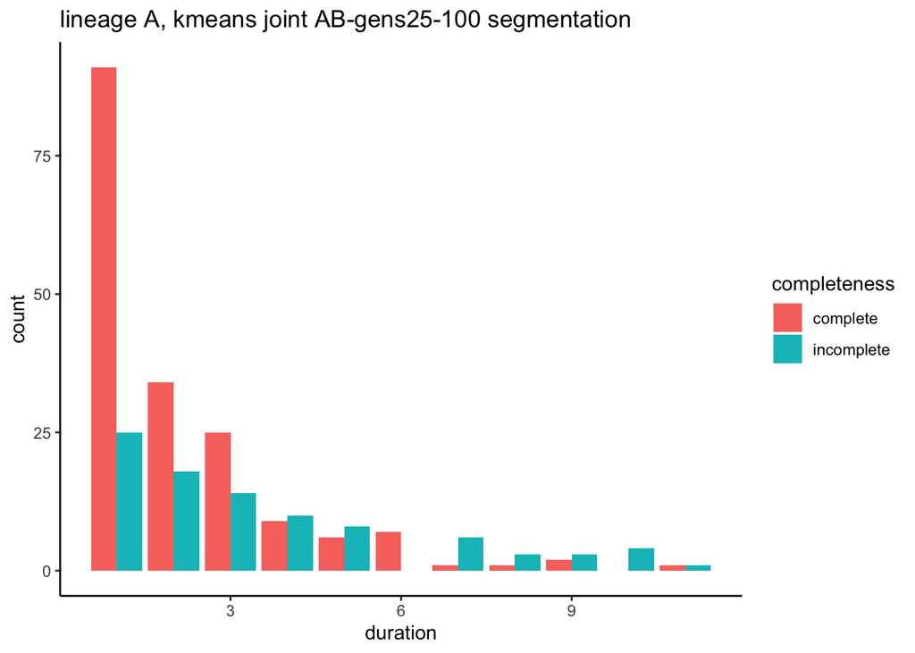

```r
A_data_for_barplot<-data.frame(duration=rep(seq(1,11),2),
                               count=c(table(factor(epimut_duration_kmeans_A[which(epimut_duration_kmeans_A$completeness==1),"duration"],levels=c(1:11))),
                                       table(factor(epimut_duration_kmeans_A[which(epimut_duration_kmeans_A$completeness==0),"duration"],levels=c(1:11)))),
                               completeness=c(rep("complete",11),rep("incomplete",11)))

# Grouped
ggplot(A_data_for_barplot, aes(fill=completeness, y=count, x=duration)) +
    geom_bar(position="dodge", stat="identity") + ggtitle("lineage A, kmeans joint AB-gens25-100 segmentation")+
  theme_classic()
```

```r
ggsave("epimut_duration_distribution_linA.pdf",dpi="retina")
##all epimutations
table(epimut_duration_kmeans_B$duration)
```

```
##
##  1  2  3  4  5  6  7  8  9 10 11 12
## 94 34 40 30 18  3  9 11  7  4  3  2
```

```r
table(epimut_duration_kmeans_B$up_or_down)
```

```
##
##   1   2
## 127 128
```

```r
table(epimut_duration_kmeans_B[which(epimut_duration_kmeans_B$completeness==0),"duration"])
```

```
##
##  1  2  3  4  5  7  8  9 10 11 12
## 15 11 12 15  9  8 11  5  4  3  2
```

```r
table(epimut_duration_kmeans_B[which(epimut_duration_kmeans_B$completeness==1),"duration"])
```

```
##
##  1  2  3  4  5  6  7  9
## 79 23 28 15  9  3  1  2
```

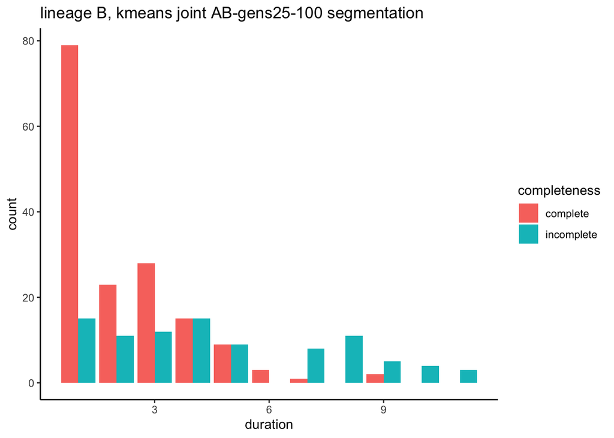

```r
B_data_for_barplot<-data.frame(duration=rep(seq(1,11),2),
                               count=c(table(factor(epimut_duration_kmeans_B[which(epimut_duration_kmeans_B$completeness==1),"duration"],levels=c(1:11))),
                                       table(factor(epimut_duration_kmeans_B[which(epimut_duration_kmeans_B$completeness==0),"duration"],levels=c(1:11)))),
                               completeness=c(rep("complete",11),rep("incomplete",11)))

# Grouped
ggplot(B_data_for_barplot, aes(fill=completeness, y=count, x=duration)) +
    geom_bar(position="dodge", stat="identity") + ggtitle("lineage B, kmeans joint AB-gens25-100 segmentation")+
  theme_classic()
```

```r
ggsave("epimut_duration_distribution_linB.pdf",dpi="retina")
epimut_duration_kmeans_both<-rbind(epimut_duration_kmeans_A,epimut_duration_kmeans_B)

##all epimutations
table(epimut_duration_kmeans_both$duration)
```

```
##
##   1   2   3   4   5   6   7   8   9  10  11  12
## 210  86  79  49  32  10  16  15  12   8   5   6
```

```r
table(epimut_duration_kmeans_both$up_or_down)
```

```
##
##   1   2
## 267 261
```

```r
table(epimut_duration_kmeans_both[which(epimut_duration_kmeans_both$completeness==0),"duration"])
```

```
##
##  1  2  3  4  5  7  8  9 10 11 12
## 40 29 26 25 17 14 14  8  8  4  6
```

```r
table(epimut_duration_kmeans_both[which(epimut_duration_kmeans_both$completeness==1),"duration"])
```

```
##
##   1   2   3   4   5   6   7   8   9  11
## 170  57  53  24  15  10   2   1   4   1
```

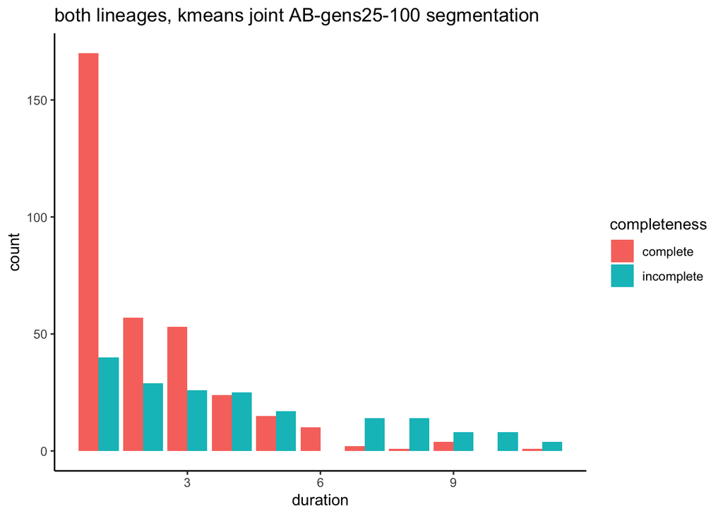

```r
both_data_for_barplot<-data.frame(duration=rep(seq(1,11),2),
                               count=c(table(factor(epimut_duration_kmeans_both[which(epimut_duration_kmeans_both$completeness==1),"duration"],levels=c(1:11))),
                                       table(factor(epimut_duration_kmeans_both[which(epimut_duration_kmeans_both$completeness==0),"duration"],levels=c(1:11)))),
                               completeness=c(rep("complete",11),rep("incomplete",11)))

# Grouped
ggplot(both_data_for_barplot, aes(fill=completeness, y=count, x=duration)) +
    geom_bar(position="dodge", stat="identity") + ggtitle("both lineages, kmeans joint AB-gens25-100 segmentation")+
  theme_classic()
```

```r
ggsave("epimut_duration_distribution_bothlineages.pdf",dpi="retina")
```

# Survival analysis

We apply survival analysis concepts to the total set of epimutations in order to obtain overall estimates of duration taking into account the fact that some epimutations reach the end of the lineage. The results obtained from lineages A and B are very consistent.

```r
epimut_duration_kmeans_A$censored<-epimut_duration_kmeans_A$completeness
epimut_duration_kmeans_B$censored<-epimut_duration_kmeans_B$completeness

library(survival)
library(survminer)
surv_A <- Surv(time = epimut_duration_kmeans_A$duration, event = epimut_duration_kmeans_A$censored)
fitA <- survfit(surv_A ~1)
summary(fitA)
```

```
## Call: survfit(formula = surv_A ~ 1)
##
##  time n.risk n.event survival std.err lower 95% CI upper 95% CI
##     1    273      91    0.667  0.0285       0.6130        0.725
##     2    157      34    0.522  0.0313       0.4644        0.587
##     3    105      25    0.398  0.0323       0.3395        0.466
##     4     66       9    0.344  0.0325       0.2855        0.414
##     5     47       6    0.300  0.0329       0.2417        0.372
##     6     33       7    0.236  0.0336       0.1787        0.312
##     7     26       1    0.227  0.0335       0.1701        0.303
##     8     19       1    0.215  0.0338       0.1581        0.293
##     9     15       2    0.186  0.0349       0.1293        0.269
##    11      6       1    0.155  0.0406       0.0931        0.259
```

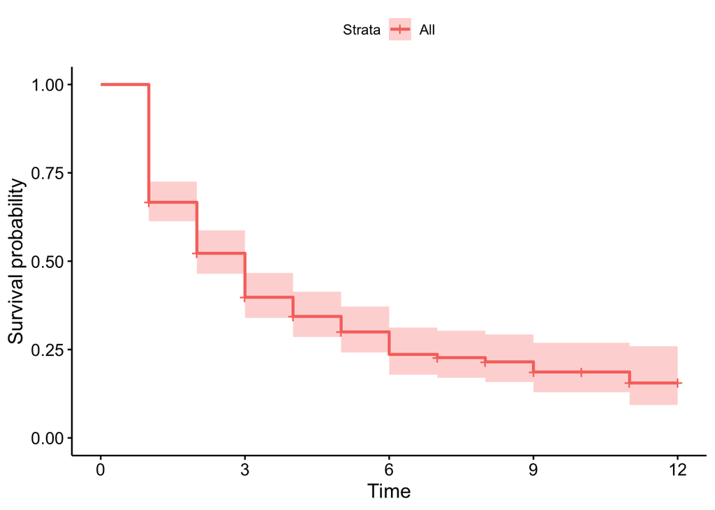

```r
ggsurvplot(fitA, data=surv_A,pval = TRUE)
```

```r
surv_B <- Surv(time = epimut_duration_kmeans_B$duration, event = epimut_duration_kmeans_B$censored)
fitB <- survfit(surv_B ~1)
summary(fitB)
```

```
## Call: survfit(formula = surv_B ~ 1)
##
##  time n.risk n.event survival std.err lower 95% CI upper 95% CI
##     1    255      79    0.690  0.0290        0.636        0.749
##     2    161      23    0.592  0.0313        0.533        0.656
##     3    127      28    0.461  0.0327        0.401        0.530
##     4     87      15    0.382  0.0329        0.322        0.452
##     5     57       9    0.321  0.0333        0.262        0.394
##     6     39       3    0.297  0.0336        0.238        0.370
##     7     36       1    0.288  0.0337        0.229        0.363
##     9     16       2    0.252  0.0379        0.188        0.339
```

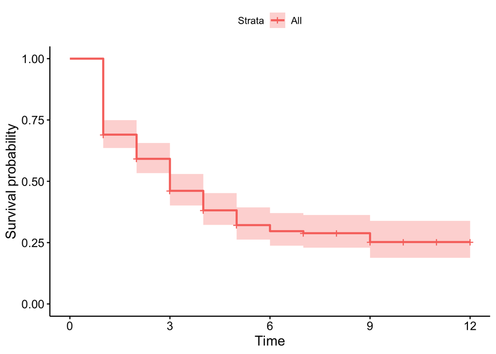

```r
ggsurvplot(fitB, data=surv_B,pval = TRUE)
```

```r
epimut_duration_kmeans_A$lineage<-rep("A",nrow(epimut_duration_kmeans_A))
epimut_duration_kmeans_B$lineage<-rep("B",nrow(epimut_duration_kmeans_B))

duration_both<-rbind(epimut_duration_kmeans_A,epimut_duration_kmeans_B)
surv_both<-Surv(time=duration_both$duration,event = duration_both$censored)
fit_both<-survfit(surv_both~lineage,data=duration_both)
summary(fit_both)
```

```
## Call: survfit(formula = surv_both ~ lineage, data = duration_both)
##
##                 lineage=A
##  time n.risk n.event survival std.err lower 95% CI upper 95% CI
##     1    273      91    0.667  0.0285       0.6130        0.725
##     2    157      34    0.522  0.0313       0.4644        0.587
##     3    105      25    0.398  0.0323       0.3395        0.466
##     4     66       9    0.344  0.0325       0.2855        0.414
##     5     47       6    0.300  0.0329       0.2417        0.372
##     6     33       7    0.236  0.0336       0.1787        0.312
##     7     26       1    0.227  0.0335       0.1701        0.303
##     8     19       1    0.215  0.0338       0.1581        0.293
##     9     15       2    0.186  0.0349       0.1293        0.269
##    11      6       1    0.155  0.0406       0.0931        0.259
##
##                 lineage=B
##  time n.risk n.event survival std.err lower 95% CI upper 95% CI
##     1    255      79    0.690  0.0290        0.636        0.749
##     2    161      23    0.592  0.0313        0.533        0.656
##     3    127      28    0.461  0.0327        0.401        0.530
##     4     87      15    0.382  0.0329        0.322        0.452
##     5     57       9    0.321  0.0333        0.262        0.394
##     6     39       3    0.297  0.0336        0.238        0.370
##     7     36       1    0.288  0.0337        0.229        0.363
##     9     16       2    0.252  0.0379        0.188        0.339
```

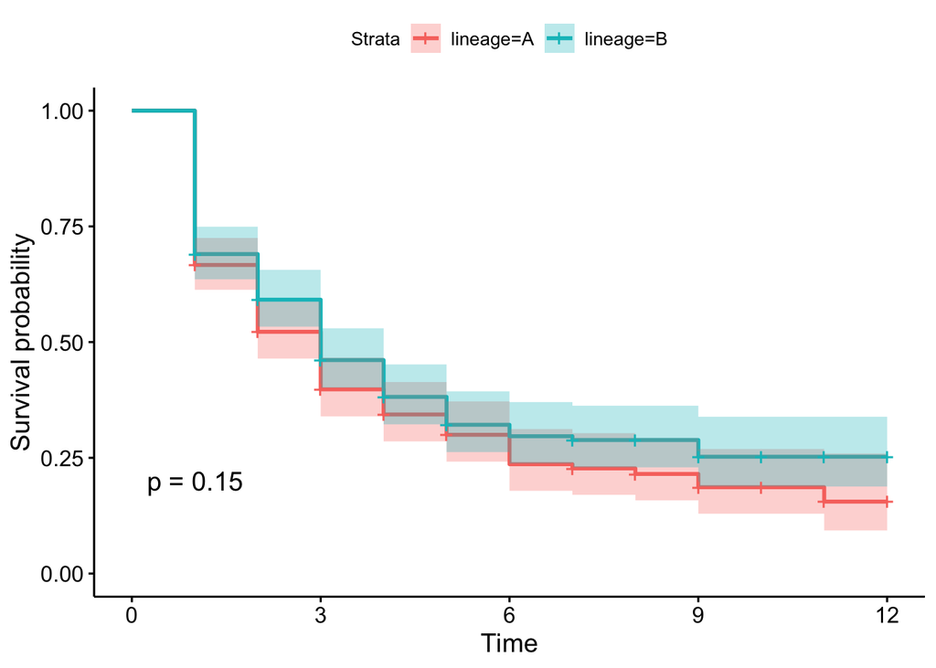

```r
ggsurvplot(fit_both, data=duration_both,conf.int = TRUE,pval = TRUE)
```

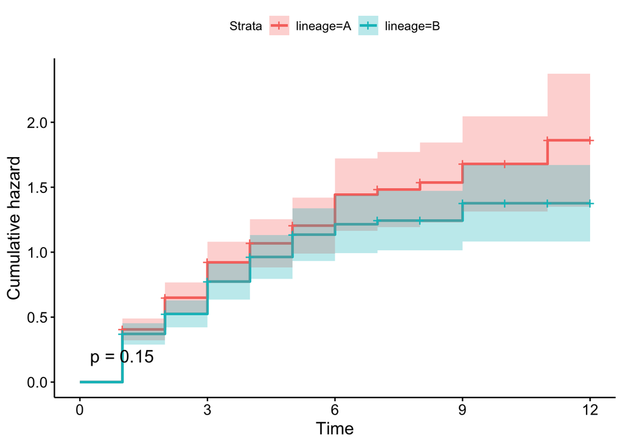

```r
ggsave("survival_curves_bylineage_notsignificant.pdf",dpi="retina")
ggsurvplot(fit_both, data=duration_both,fun = "cumhaz",conf.int = TRUE,pval = TRUE)
```